El clasificador de Bayes produce la menor tasa de error de prueba. Demostración:

Se tiene que la tasa de error de prueba está dada por:
$$Average(I(y_0 \neq \hat{y}_0))=E[I(y_0 \neq
\hat{y}_0)]$$

Se supone que se está trabajando con dos clases (Aunque también se puede generalizar para $n$ clases). Donde se suponen los siguientes datos de prueba:

$$y_{0i} = \left\lbrace \begin{array}{ll}
0 ~, ~ i=1,2,...,n;~Siendo~x_{0i}~los~datos~de~prueba \\
1
\end{array}
\right.$$

Y su respectivo clasificador de Bayes está dado por

$$P(y_{0i} = j |X_{0i}= x_{01}),~ con ~ j
= 0,1$$

Donde
$$\underbrace{P(y_{0i} = 0 |
x_{0i})}_{P_0} ~ > ~ \acute{o} ~ < ~ \underbrace{P(y_{0i} = 1
|x_{0i})}_{P_1}$$

Se toma la máxima probabilidad de las dos probabilidades condicionales anteriores, es decir $máx\{P_0, P_1\}$

El error se minimiza cuando $máx\{P_0, P_1\}$ lleva a aciertos, el cual se reduce al minimizar la tasa de error promedio cuando se usa una indicadora (Clasificador):

La siguiente igualdad es un resultado de probabilidad (Solo se cumple para la indicadora):

$$\underbrace{E[I(\underbrace{y_{0i}\neq
\widehat{y}_{0i}) }_{A})|x_{0i}]}_{Se~ desea~ minimizar}=P(y_{0i}\neq
\widehat{y}_{0i}|x_{0i})=0*P(I_A=0)+1*(I_A=1)$$

El menor valor que puede obtener es:

$E[I_{A}|x_{0i}] = 0$ que sucede cuando $y_{0i}=\hat{y}_{0i}~~$ $\Longrightarrow~~$ $(y_{0i} - \hat{y}_{0i}) = 0$ $~~\Longrightarrow~~$ $(y_{0i} - \hat{y}_{0i})^2=0$

Seguidamente, se intentará probar que $y_{0i} = \hat{y_{0i}}$ produce el menor error Cuando se usa el método de Bayes.

Sea $f(y) = (y - \hat{y})^2$. Donde $E[f(y)] = E[(y - \hat{y})^2]$ es el $MSE$, que es mínimo justamente cuando $y_i$ es el promedio de los errores.

Posteriormente, se utiliza una variable binaria que indiqué cuando se comete o no un error:

$I\{y_{0i} \neq \hat{y}_{01}\}$ el cual toma valores de $\left\{ \begin{aligned} 0\\ 1\\ \end{aligned} \right.$ al igual que $y_{0i}$ y el clasificador $\hat{y}_{0i}$.

Entonces $(y_{0i} - \hat{y}_{0i})^2 = I\{y_{0i} \neq \hat{y}_{0i}\}$, esta igualdad se prueba a continuación:

sea:

$$y_{0i} = I\{y_{0i} = j\}~~ y ~~
\hat{y}_{0i} = I\{\hat{y}_{0i} = j\} \longrightarrow ~~ ambas~ son
~indicadoras.$$

Utilizando la función de perdida

$$\delta(x) = (y_{0i} - \hat{y}_{0i})^2 =
[I\{y_{0i} = j\} - I\{\hat{y}_{0i} = j\}]^2$$

Se prueba que:

$$\begin{array}{ c | c }
[I\{y_{0i} = j\} - I\{\hat{y}_{0i} = j\}]^2 & I\{y_{0i} \neq\
\hat{y}_{0i}\} \\
\hline
(1 - 1)^2 = 0 & 0 \\
(1 - 0)^2 = 1 & 1 \\
(0 - 1)^2 = 1 & 1 \\
(0 - 0)^2 = 0 & 0 \\
\end{array}$$

Así que $(y_{0i} - \hat{y}_{0i})^2$ es equivalente a $I\{y_{0i} \neq \hat{y}_{0i} \}$

Este proceso de clasificación esta basado en la regla de clasificación de Bayes por lo tanto minimiza $(y_{0i} - \hat{y}_{0i})^2$ y minimiza la tasa de error de prueba.

Esta expresión anterior se demostrará a continuación:

Se define la función de pérdida posterior como:

$$L(y_{0i},\delta(x)) =
(y_{0i}-\hat{y}_{0i})^2 = [I\{y_{0i}=j\}-I\{\hat{y}_{0i}=j\}]^2$$
Consideremos $y = y_{0i}$, $x= x_{0i}$ para facilitar el proceso algebráico a continuación:

$$L(y,\delta(x)) = (y-\hat{y})^2 =
[I\{y=j\}-I\{\hat{y}=j\}]^2$$

Sea la función de pérdida posterior esperada:

$$\begin{aligned}
\gamma(y,\delta(x)) & = E[L(y,\delta(x))|X=x]\\
& = E[(y-\hat{y})^2|X=x]\\
& = E[(y-E[y|x]+E[y|x]-\hat{y})^2|X=x]\\
& = E[(y-E[y|x])^2 + (E[y|x]-\hat{y})^2 +
2(y-E[y|x])(E[y|x]-\hat{y})|X=x]\\
& = E[(y-E[y|x])^2|X=x]+(E[y|x]-\hat{y})^2 + 2
\underbrace{E[(y-E[y|x])(E[y|x]-\hat{y})|X=x]}_{\blacksquare}
\end{aligned}$$

$$\begin{aligned}
\blacksquare E[(y-E[y|x])(E[y|x]-\hat{y})|X=x] & = E[y \cdot E[y|x]
- y\cdot\hat{y}-E^2[y|x] + \hat{y} \cdot E[y|x]|X=x]\\
& = \color{blue}{E[y|x]E[y|x]} -
\color{red}{\hat{y}E[y|x]}-\color{blue}{E^2[y|x]} +
\color{red}{\hat{y}E[y|x]}\\
& = 0
\end{aligned}$$

Por lo tanto

$$\gamma(y, \delta(x)) =
E[(y-E[y|x])^2|X=x]+(E[y|x]-\hat{y})^2
\geq
\underbrace{E[(y-E[y|x])^2|X=x]}_{Cota~inferior:~mínimo}$$

Por lo tanto el mínimo valor que toma $\gamma(y, \delta(x))$ es:

$$E[(y-E[y|x])^2|X=x] ~ \text{que es
cuando}~ (E[y|x]-\hat{y})^2 = 0$$

Dado que $E[(y-E[y|x])^2|X=x]$ es la cota mínima, se prueba que esta utiliza el estimador de Bayes para estimar $\hat{y}$ y lo esta utilizando mediante $E[y|x]: (E[(y- \color{purple}{E[y|x]})^2|X=x])$ donde:

$$\widehat{y}=E[y|x]=\underbrace{P(y|x)}_{Estimador
~ de~ Bayes}$$

|  | x | Tiempo |
| --- | --- | --- |
|  | Min. : 0 | Min. : 439.6 |
|  | 1st Qu.: 90 | 1st Qu.: 5440.6 |
|  | Median :180 | Median :11804.3 |
|  | Mean :180 | Mean :11047.4 |
|  | 3rd Qu.:270 | 3rd Qu.:16101.2 |
|  | Max. :360 | Max. :22600.5 |

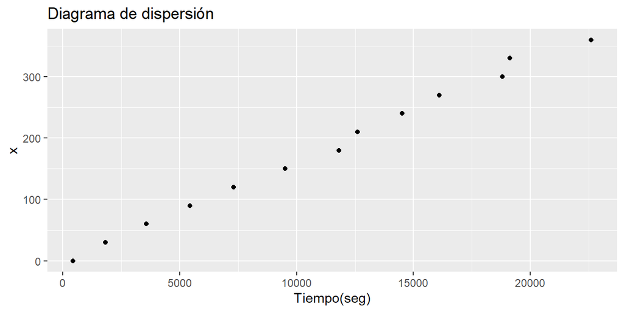

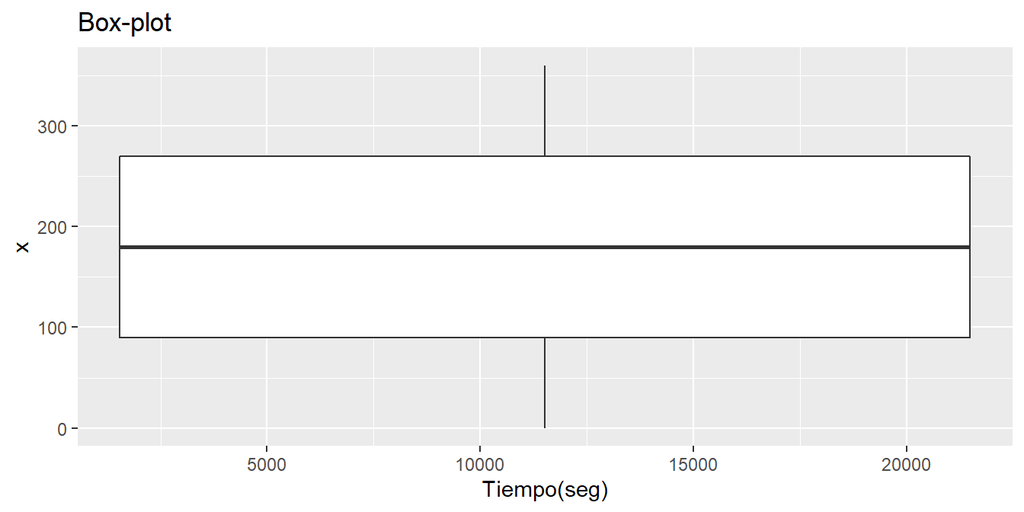

**Matriz de Autocorrelación**

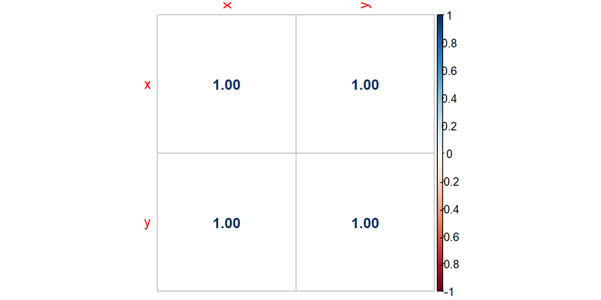

**Modelo lineal**

$$Y = \beta_0 + \beta_1x+\epsilon \: ; \:
\epsilon \sim N(0, \sigma^2)$$

```
##
## Call:
## lm(formula = db$y ~ db$x)
##
## Residuals:
##    Min     1Q Median     3Q    Max
## -984.8 -227.0 -162.5  268.5  756.9
##
## Coefficients:
##             Estimate Std. Error t value Pr(>|t|)
## (Intercept)  171.420    262.566   0.653    0.527
## db$x          60.422      1.238  48.816 3.27e-14 ***
## ---
## Signif. codes:  0 '***' 0.001 '**' 0.01 '*' 0.05 '.' 0.1 ' ' 1
##
## Residual standard error: 500.9 on 11 degrees of freedom
## Multiple R-squared:  0.9954, Adjusted R-squared:  0.995
## F-statistic:  2383 on 1 and 11 DF,  p-value: 3.271e-14
```

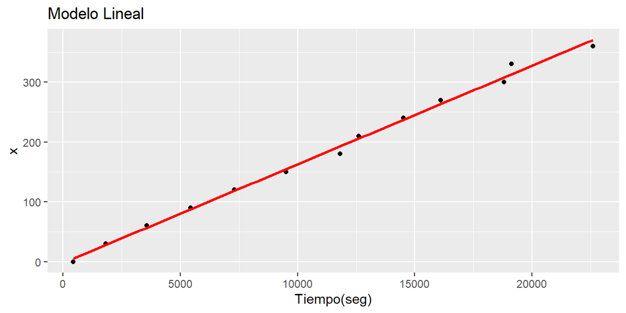

**Test de Spearmn**

El test de Spearman es la contra parte no parametrica del test de correlación de Pearson, ambos buscan encontrar y cuantificar el grado de relación lineal entre dos variables. partiendo de lo anterior, como vimos en la sección anterior, las variables x e y presentan un muy buen ajuste lineal que deriva en una dependencia bastante marcada, el test de Spearman nos permitirá corroborar esta dependencia y adicionalmente, nos permitiría calcular un valor para la correlación entre las mismas. como veremos a continuación.

Prueba unilateral derecha:

- $H_0:$ X e Y son mutuamente independientes.
- $H_a:$ Existe una tendencia a formar parejas entre los valores grandes de X e Y.

Estadístico de prueba: El test de Pearson, presenta dos tipos de estadísticos de prueba, uno cuando existen repeticiones entre las observaciones, y otro en caso contrario, para el estudio que estamos llevando a cabo se verifico dicha situación, y nos encontramos con que efectivamente no tenemos ninguna observación repetida, por lo cual el siguiente es el estadístico de

Prueba a utilizar:

$\rho = 1 - \frac{6T}{n(n^2-1)}$ donde $T = \sum_{i=1}^{n} [R(x_i)-R(y_i)]^2$

Criterio de rechazo: $Rc=[\rho/\rho <- W\alpha]$ donde $W\alpha$ valor tabulado en la tabla A.10 con la aproximación normal. $VP = P(Z < \rho\sqrt{n-1})$ para un valor de $\alpha = 0.05$ se rechaza $H_0$ si el Valor p $< \alpha$

```
##
##  Spearman's rank correlation rho
##
## data:  db$x and db$y
## S = 0, p-value < 2.2e-16
## alternative hypothesis: true rho is greater than 0
## sample estimates:
## rho
##   1
```

$$Pr(Y = J \mid X = x_0) \approx
\frac{1}{K} \sum_{i \in N_0}I(y_i=j)$$

Base de datos

| X1 | X2 | X3 | Y |
| --- | --- | --- | --- |
| 0 | 3 | 0 | Red |
| 2 | 0 | 0 | Red |
| 0 | 1 | 3 | Red |
| 0 | 1 | 2 | Green |
| -1 | 0 | 1 | Green |
| 1 | 1 | 1 | Red |

Usando la distancia euclidiana entre dos punto $u$ y $v$ definida como:

$$d(u, v) = \sqrt{(u_1-
v_1)^2+(u_2-v_2)^2+(u_3-v_3)^2}$$
Calculamos la distancia entre cada observación y el punto $P$ con características $X_1 = X_2 = X_3 = 0$

- $d(p, x_1) = \sqrt{(p_1- x_{1,1})^2+(p_2-x_{1,2})^2+(p_3-x_{1,3})^2} = \sqrt{(0-0)^2 + (0-3)^2 +(0-0)^2} = \sqrt{0 + 9 + 0} = \sqrt{9} = 3$
- $d(p, x_2) = \sqrt{(p_1- x_{2,1})^2+(p_2-x_{2,2})^2+(p_3-x_{2,3})^2} = \sqrt{(0-2)^2 + (0-0)^2 + (0-0)^2} = \sqrt{4 + 0 + 0} = \sqrt{4} = 2$
- $d(p, x_3) = \sqrt{(p_1- x_{3,1})^2+(p_2-x_{3,2})^2+(p_3-x_{3,3})^2} = \sqrt{(0-0)^2 + (0-1)^2 + (0-3)^2} = \sqrt{0 + 1 + 9} = \sqrt{10} = 3.162278$
- $d(p, x_4) = \sqrt{(p_1- x_{4,1})^2+(p_2-x_{4,2})^2+(p_3-x_{4,3})^2} = \sqrt{(0-0)^2 + (0-1)^2 + (0-2)} = \sqrt{0 + 1 + 4} = \sqrt{5} = 2.236068$
- $d(p, x_5) = \sqrt{(p_1- x_{5,1})^2+(p_2-x_{5,2})^2+(p_3-x_{5,3})^2} = \sqrt{(0+1)^2 + (0-0)^2 + (0-1)^2} = \sqrt{1 + 0 + 1} = \sqrt{2} = 1.414214$
- $d(p, x_6) = \sqrt{(p_1- x_{6,1})^2+(p_2-x_{6,2})^2+(p_3-x_{6,3})^2} = \sqrt{(0-1)^2 + (0-1)^2 + (0-1)^3} = \sqrt{1 + 1 +1} = \sqrt{3} = 1.732051$

Ahora procedemos a calcularla con R:

```r
point <- c(0, 0, 0)

dist_eucl <- function(x){
  ans <- c()
  for (i in 1:nrow(x)){
    xi <- as.numeric(t(as.vector(x[i, ])))
    result <- sqrt(sum((xi-point)^2))
    ans <- append(ans, result)
  }
  return (ans)
}

db <- mutate(db, dist = dist_eucl(db[1:3]))
```

Distancia a cada observación desde el punto $X_1 = X_2 = X_3 = 0$

| Observación | Grupo | Distancia Euclidiana |
| --- | --- | --- |
| 1 | Red | 3.000000 |
| 2 | Red | 2.000000 |
| 3 | Red | 3.162278 |
| 4 | Green | 2.236068 |
| 5 | Green | 1.414214 |
| 6 | Red | 1.732051 |

Con una selección de K = 1. Knn identifica la observación más cercana al punto con características $X_1 = X_2 = X_3 = 0$ y en este caso la observación mas cercana es la **numero 5** con una distancia de **1.414214**. Dando así Knn una estimación de $1/1$ de pertenecer al grupo **Green**. Por ende la estimación es pertenecer a la clase **Green**.

Usando la librería **Class** y la funcion **knn()** se obtiene:

```r
library(class)
point <- c(0,0,0)
n <- 6

model <- knn(train=db[, -4], test=point, cl=db[1:6, 4], k = 1)
kable(model, col.names = c("Predicción"))
```

| Predicción |
| --- |
| Green |

Con una selección de K = 3. Knn identifica las 3 observaciones más cercanas al punto con características $X_1 = X_2 = X_3 = 0$ y en este caso las observaciones mas cercana son la **numero 5**, la **numero 6** y la **numero 2** que consisten en 2 observaciones de la clase **Red** y una observación de la clase **Green**, dando como restulado una estimación de $2/3$ de pertenecer a la clase **Red** y $1/3$ de pertenecer a la clase **Green**. Por consiguiente se estima pertenecer a la clase **Red**.

```r
library(class)
point <- c(0,0,0)
n <- 6

model <- knn(train=db[, -4], test=point, cl=db[,4], k = 3)
kable(model, col.names = c("Predicción"))
```

| Predicción |
| --- |
| Red |

Si la frontera de decisión de Bayes en este problema es altamente no lineal, ¿esperaríamos que el mejor valor de K fuera grande o pequeño? ¿Por qué?

Cuando K empieza a crecer el modelo empieza a perder flexibilidad tomando una forma lineal. Con un k pequeño el modelo es mas flexible. Con esto en mente el mejor valor para k es cuando k toma un valor pequeño.

Inicialmente cargamos los datos de la siguiente manera:

```r
library(ISLR)
College=ISLR::College
kable(head(College))
```

|  | Private | Apps | Enroll | Top10perc | Top25perc |
| --- | --- | --- | --- | --- | --- |
| Abilene Christian University | Yes | 1660 | 721 | 23 | 52 |
| Adelphi University | Yes | 2186 | 512 | 16 | 29 |
| Adrian College | Yes | 1428 | 336 | 22 | 50 |
| Agnes Scott College | Yes | 417 | 137 | 60 | 89 |
| Alaska Pacific University | Yes | 193 | 55 | 16 | 44 |
| Albertson College | Yes | 587 | 158 | 38 | 62 |

Para esta sección, mostramos la estructura de los datos, la cual, a groso modo cuenta con datos de 777 universidades

```r
fix(College)
rownames(College)=College[,1]
College=College [,-1]
fix(College)
```

Luego, calculamos el resumen estadístico general para todas las variables de la base de datos, este resumen es muy importante, dado que nos da una mejor visión sobre la estructura y el comportamiento de nuestra información.

```
##  Private        Apps           Accept          Enroll       Top10perc
##  No :212   Min.   :   81   Min.   :   72   Min.   :  35   Min.   : 1.00
##  Yes:565   1st Qu.:  776   1st Qu.:  604   1st Qu.: 242   1st Qu.:15.00
##            Median : 1558   Median : 1110   Median : 434   Median :23.00
##            Mean   : 3002   Mean   : 2019   Mean   : 780   Mean   :27.56
##            3rd Qu.: 3624   3rd Qu.: 2424   3rd Qu.: 902   3rd Qu.:35.00
##            Max.   :48094   Max.   :26330   Max.   :6392   Max.   :96.00
##    Top25perc      F.Undergrad     P.Undergrad         Outstate
##  Min.   :  9.0   Min.   :  139   Min.   :    1.0   Min.   : 2340
##  1st Qu.: 41.0   1st Qu.:  992   1st Qu.:   95.0   1st Qu.: 7320
##  Median : 54.0   Median : 1707   Median :  353.0   Median : 9990
##  Mean   : 55.8   Mean   : 3700   Mean   :  855.3   Mean   :10441
##  3rd Qu.: 69.0   3rd Qu.: 4005   3rd Qu.:  967.0   3rd Qu.:12925
##  Max.   :100.0   Max.   :31643   Max.   :21836.0   Max.   :21700
##    Room.Board       Books           Personal         PhD
##  Min.   :1780   Min.   :  96.0   Min.   : 250   Min.   :  8.00
##  1st Qu.:3597   1st Qu.: 470.0   1st Qu.: 850   1st Qu.: 62.00
##  Median :4200   Median : 500.0   Median :1200   Median : 75.00
##  Mean   :4358   Mean   : 549.4   Mean   :1341   Mean   : 72.66
##  3rd Qu.:5050   3rd Qu.: 600.0   3rd Qu.:1700   3rd Qu.: 85.00
##  Max.   :8124   Max.   :2340.0   Max.   :6800   Max.   :103.00
##     Terminal       S.F.Ratio      perc.alumni        Expend
##  Min.   : 24.0   Min.   : 2.50   Min.   : 0.00   Min.   : 3186
##  1st Qu.: 71.0   1st Qu.:11.50   1st Qu.:13.00   1st Qu.: 6751
##  Median : 82.0   Median :13.60   Median :21.00   Median : 8377
##  Mean   : 79.7   Mean   :14.09   Mean   :22.74   Mean   : 9660
##  3rd Qu.: 92.0   3rd Qu.:16.50   3rd Qu.:31.00   3rd Qu.:10830
##  Max.   :100.0   Max.   :39.80   Max.   :64.00   Max.   :56233
##    Grad.Rate
##  Min.   : 10.00
##  1st Qu.: 53.00
##  Median : 65.00
##  Mean   : 65.46
##  3rd Qu.: 78.00
##  Max.   :118.00
```

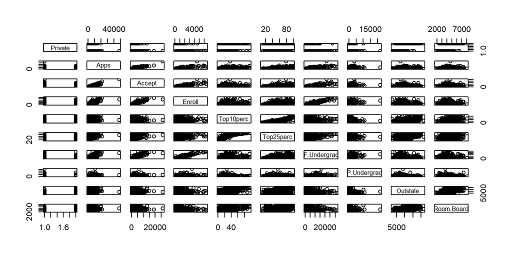

Inicialmente observamos una alta asociación entre las variables número de aplicaciones recibidas(apps) y numero de aplicaciones aceptadas(accept), esto indica que en general, que a medida que aumenta la recepción de aplicaciones aumenta también su aceptación, lo cual tiene mucho sentido. De la misma manera existe una alta asociación entre aplicaciones aceptadas(accept) y número de estudiantes matriculados(enroll). Otra relación bastante fuerte es entre los estudiantes nuevos que hacen parte del 10% y 25% superior de secundaria, indica que hacer parte de estos porcentajes puede incrementar la probabilidad e asistir a una universidad.

Luego, agregamos un gráfico entre universidad publica o privada y el numero de matriculas fuera del estado.

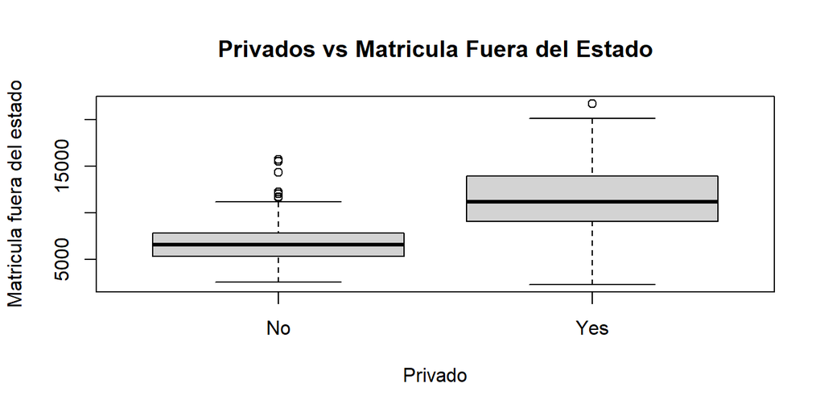

En esta sección realizamos una agrupación en una nueva variable categórica llamada Elite, donde los estudiantes con un rendimiento superior del 10 % en secundaria, se agrupan en si, siempre y cuando la universidad contenga 50 o mas de ellos, en caso contrario se agrupan en no, el resultado fue el siguiente:

|  | Cantidad |
| --- | --- |
| Yes | 78 |
| No | 699 |

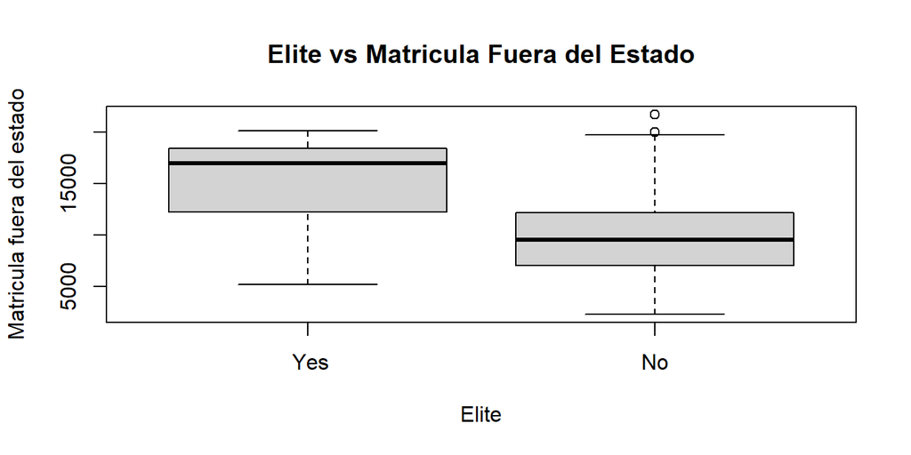

Los siguientes histogramas muestran la distribución de algunas de las variables, sin embargo, no es posible concluir acerca de una posible distribución.

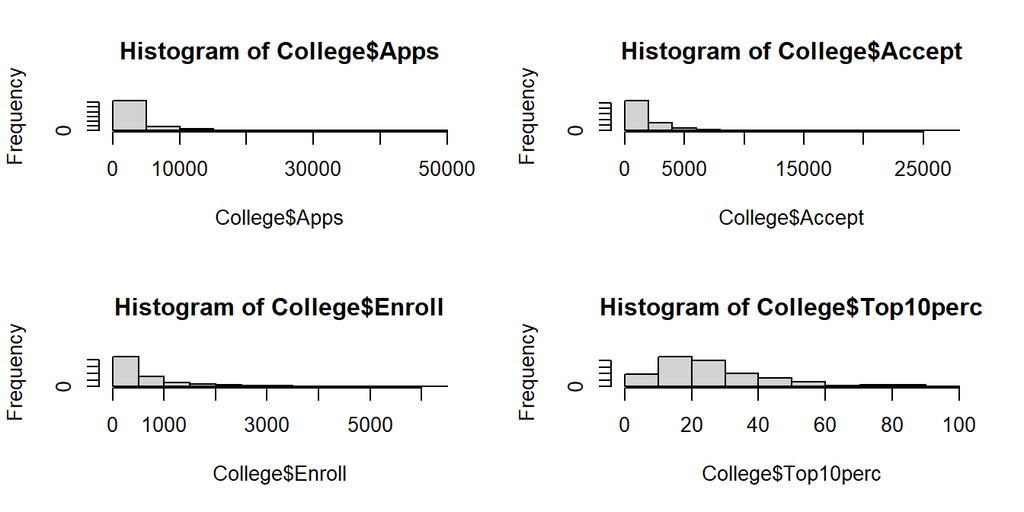

Continúe explorando los datos.

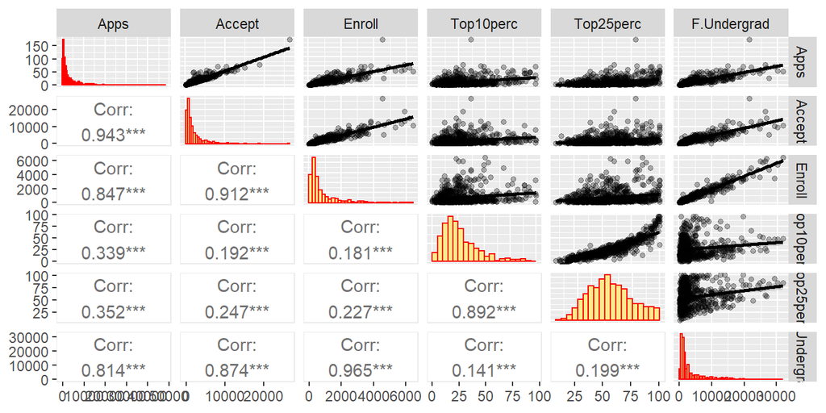

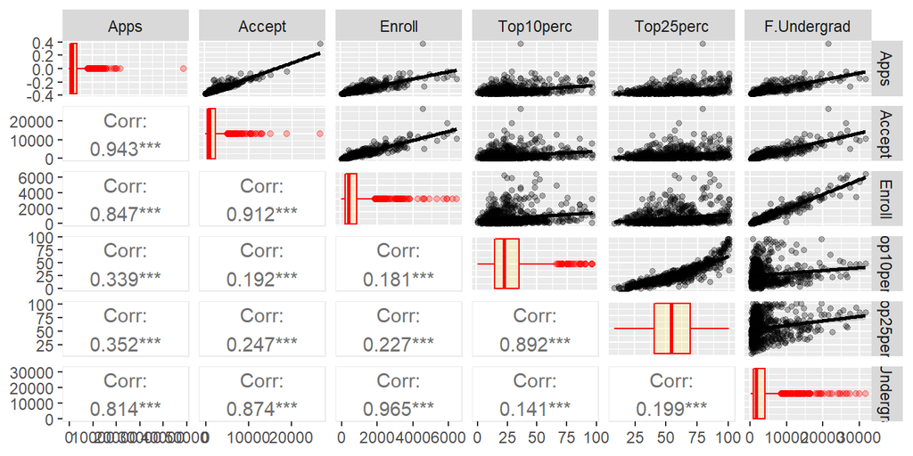